# Analiza filmów: projekt

## 2.6 Glosy

Można powiedzieć, że liczba głosów odnosi się do popularności filmów. Jak zostało wspomniane na wstępie, ocena filmu nie jest po prostu średnią wszystkich ocen, więc można śmiało użyć tej zmiennej w modelu. Na początku jednak należy jej się bliżej przyjrzeć.

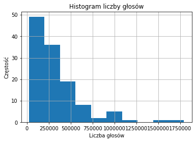

```python
filmy['Glosy'].hist(bins=10)
plt.title("Histogram liczby głosów")
plt.xlabel('Liczba głosów')
plt.ylabel('Częstość')
```

Widać definitywnie, że przydatne może okazać się użycie logarytmu. Ogon liczby głosów jest długi przez obecność filmów o bardzo dużej popularności.

```
array([[1.        , 0.68378401],
       [0.68378401, 1.        ]])
```

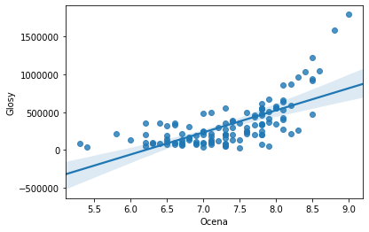

```python
sns.regplot(filmy['Ocena'], filmy['Glosy'])
np.corrcoef(filmy['Ocena'], filmy['Glosy'])
```

Korelacja jest dość wysoka (większe zainteresowanie skorelowane jest z lepszą oceną), ale widać, że linia prosta to nie najlepsze dopasowanie do danych.

```
array([[1.       , 0.6648969],
       [0.6648969, 1.       ]])
```

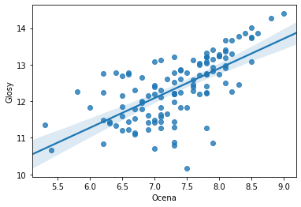

```python
sns.regplot(filmy['Ocena'], np.log(filmy['Glosy']))
np.corrcoef(filmy['Ocena'], np.log(filmy['Glosy']))
```

Po zlogarytmizowaniu przedstawia się to znacznie lepiej. Użycie logarytmu na zmiennej Glosy będzie musiało być rozpatrzone przy tworzeniu modelu. Które z filmów powodują konieczność stosowania logarytmu?

|  | Aktor | Rezyser | Tytul | Gatunek | Dlugosc | Ocena | Glosy | Box.office | Ocena_rezysera | Ocena_aktora | Oscary |
| --- | --- | --- | --- | --- | --- | --- | --- | --- | --- | --- | --- |
| 15 | Christian Bale | Christopher Nolan | The Dark Knight Rises | Action,Thriller | 164 | 8.5 | 1222645 | 448.13 | 8.71 | 8.68 | 0 |
| 18 | Christian Bale | Christopher Nolan | The Dark Knight | Action,Crime,Drama | 152 | 9.0 | 1791916 | 533.32 | 8.71 | 8.68 | 2 |
| 46 | Jamie Foxx | Quentin Tarantino | Django Unchained | Drama,Western | 165 | 8.4 | 1039115 | 162.80 | 8.88 | 8.01 | 2 |
| 61 | Leonardo DiCaprio | Christopher Nolan | Inception | Action,Adventure,Sci-Fi | 148 | 8.8 | 1583625 | 292.57 | 8.71 | 8.97 | 4 |
| 69 | Matthew McConaughey | Christopher Nolan | Interstellar | Adventure,Drama,Sci-Fi | 169 | 8.6 | 1047747 | 187.99 | 8.71 | 8.71 | 1 |

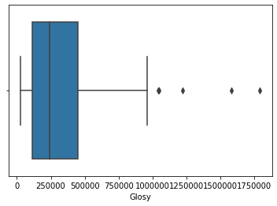

```python
sns.boxplot(filmy['Glosy'])
filmy.loc[filmy['Glosy']>1000000]
```

Wszystkie z tytułów brzmią znajomo, a filmy z Batmanem po raz kolejny przejmują czołówkę tabeli. Możliwe, że konieczne będzie usunięcie wskazanych filmów ze zbioru danych. Ale co jeśli zastosuje się logarytm? Może wskazany problem zniknie?

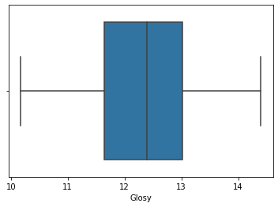

```python
sns.boxplot(np.log(filmy['Glosy']))
```

Rzeczywiście, problem zniknął.

Wiemy już jakie filmy są najpopularniejsze, a które są najmniej popularne?

```python
filmy.sort_values('Glosy').head(5)
```

|  | Aktor | Rezyser | Tytul | Gatunek | Dlugosc | Ocena | Glosy | Box.office | Ocena_rezysera | Ocena_aktora | Oscary |
| --- | --- | --- | --- | --- | --- | --- | --- | --- | --- | --- | --- |
| 2 | Adam Driver | Jim Jarmusch | Paterson | Comedy,Drama,Romance | 118 | 7.5 | 26089 | 2.14 | 8.09 | 8.01 | 0 |
| 11 | Chris Hemsworth | Michael Mann | Blackhat | Crime,Drama,Mystery | 133 | 5.4 | 43085 | 7.10 | 7.95 | 8.35 | 0 |
| 112 | Laura Dern | David Lynch | Inland Empire | Drama,Mystery,Thriller | 180 | 7.0 | 44227 | 4.04 | 8.60 | 7.91 | 0 |
| 3 | Andrew Garfield | Martin Scorsese | Silence | Adventure,Drama,History | 161 | 7.3 | 49190 | 7.08 | 8.60 | 8.32 | 0 |
| 105 | Elle Fanning | Nicolas Winding Refn | The Neon Demon | Horror,Thriller | 118 | 6.2 | 50359 | 1.33 | 7.86 | 7.23 | 0 |

Wśród podanych filmów znajomy wydaje się być film Blackhat, który już pojawiał się jako słabo oceniany film.

Co wspólnego może mieć zmienna Glosy z oceną aktora? Czy lepiej oceniani aktorzy grają w popularniejszych filmach?

```
array([[1.        , 0.31941494],
       [0.31941494, 1.        ]])
```

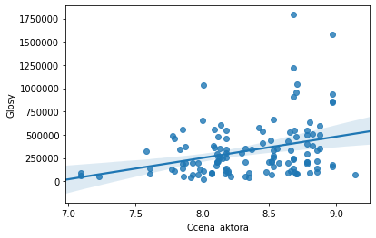

```python
sns.regplot(filmy['Ocena_aktora'], filmy['Glosy'])
np.corrcoef(filmy['Ocena_aktora'], filmy['Glosy'])
```

Korelacja, choć słaba, jednak istnieje. Ciekawi punkt dla którego ocena aktora jest najwyższa, a popularność prawie najmniejsza. Joaquin Phoenix nie miał jeszcze wtedy okazji zagrać w Jokerze. Gdyby dane z IMDB były aktualne, z pewnością wyglądałoby to inaczej. Widać też, że najpopularniejsze filmy (powyżej 750 tys. głosów) mają prawie zawsze wysoką notę głównego aktora.

```
array([[1.        , 0.46876366],
       [0.46876366, 1.        ]])
```

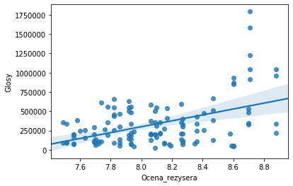

```python
sns.regplot(filmy['Ocena_rezysera'], filmy['Glosy'])
np.corrcoef(filmy['Ocena_rezysera'], filmy['Glosy'])
```

Podobna zależność jest widoczna dla reżyserów. Zastanawiają pionowe rzędy kropek przy wysokich ocenach reżyserów. Pamiętaćjednak należy, że jeden reżyser może mieć parę filmów, w rzeczywistości więc są to punkty odnoszące się wyłącznie do paru reżyserów.

Badanie popularności według aktorów/reżyserów nie ma jednak większego sensu, ponieważ niektórzy aktorzy znani z jednego hitu (np. w tej stawce jest to Matthew McConaughey z Interstellara) będą mieli wyższą średnią ocenę niż średni aktorzy z wielu produkcji. Ponadto, popularność tyczy się raczej całokształtu. Z kolei badanie to warto odnieść do gatunków. Poniżej zaprezentowane zostanie podsumowanie względem tej zmiennej.

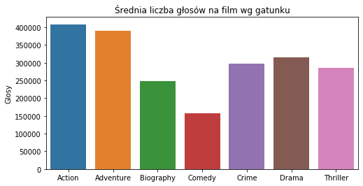

```python
plt.figure(figsize=(8, 4))
sns.barplot(filmy[['Glosy']].groupby(gatunek_filmu).mean().index,
        filmy['Glosy'].groupby(gatunek_filmu).mean())
plt.title("Średnia liczba głosów na film wg gatunku")
plt.xlabel("")
```

Interesujący w tym zestawieniu jest niski wynik komedii oraz wysoki poziom filmów akcji, mimo dużej liczby filmów. Ciekawi też wysoki wynik thrillerów, mimo niedużej średniej oceny tego gatunku (najwidoczniej jest to gatunek na tyle uniwersalny, że nie zawadzają nieco gorsze wyniki filmów) . Zagadkę może rozwiązać wykonanie wykresu z pominięciem największych hitów.

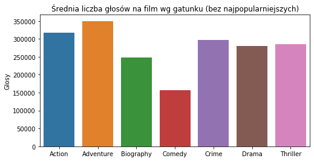

```python
filmy_bez_najpopularniejszych = filmy.loc[filmy['Glosy']<1000000]
plt.figure(figsize=(8, 4))
sns.barplot(filmy_bez_najpopularniejszych[['Glosy']].groupby(gatunek_filmu).mean().index,
        filmy_bez_najpopularniejszych['Glosy'].groupby(gatunek_filmu).mean())
plt.title("Średnia liczba głosów na film wg gatunku (bez najpopularniejszych)")
plt.xlabel("")
```

Filmy akcji obniżyły swoją lokatę, widać więc jak bardzo najpopularniejsze filmy podnoszą średnią popularność filmów akcji.

Pozostaje jeszcze kwestia długości filmu.

```
array([[1.        , 0.37757757],
       [0.37757757, 1.        ]])
```

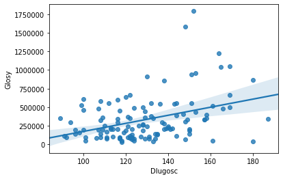

```python
sns.regplot(filmy['Dlugosc'], filmy['Glosy'])
np.corrcoef(filmy['Dlugosc'], filmy['Glosy'])
```

Można zauważyć, że filmy popularne są zazwyczaj nieco dłuższe niż pozostałe filmy. Po raz kolejny okazuje się, że długi film to niekoniecznie nudny film. Ale czy dochodowy? Tego dowiemy się w kolejnym podrozdziale.

## 2.7 Box.office

Zmienna Box.office informuje o dochodzie filmu, liczonym w milionach dolarów. Poniżej zaprezentowany zostanie histogram prezentujący rozkład tych kwot dla badanych filmów.

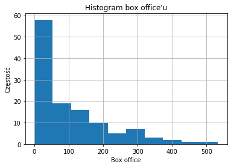

```python
filmy['Box.office'].hist(bins=10)
plt.title("Histogram box office'u")
plt.xlabel('Box office')
plt.ylabel('Częstość')
```

Wydaje się, że również tutaj przydatny będzie logarytm. Większość filmów zamyka się w przedziale do około 50 mln $, jednak są filmy, które osiągnęły nawet dziesięciokrotnie większy sukces kasowy. Dla pełności obrazu warto też zaglądnąć do wykresu prezentującego zestawienie zmiennej Box.office i zmiennej Ocena.

```
array([[1.        , 0.28438282],
       [0.28438282, 1.        ]])
```

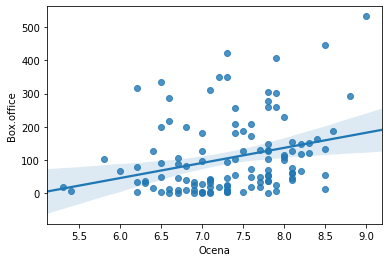

```python
sns.regplot(filmy['Ocena'], filmy['Box.office'])
np.corrcoef(filmy['Ocena'], filmy['Box.office'])
```

Wykres nie wygląda tak, jakby logarytm miał uprościć sprawę. Widać, że generalnie jest słaba korelacja oceny filmu z jego box officem.

```
array([[1.        , 0.29114237],
       [0.29114237, 1.        ]])
```

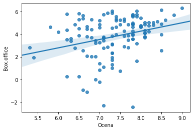

```python
sns.regplot(filmy['Ocena'], np.log(filmy['Box.office']))
np.corrcoef(filmy['Ocena'], np.log(filmy['Box.office']))
```

Logarytm rzeczywiście nie uprościł sprawy. Ze względu jednak na skalę wielkości, użycie logarytmu może być zasadną ideą. A co z outlierami?

|  | Aktor | Rezyser | Tytul | Gatunek | Dlugosc | Ocena | Glosy | Box.office | Ocena_rezysera | Ocena_aktora | Oscary |
| --- | --- | --- | --- | --- | --- | --- | --- | --- | --- | --- | --- |
| 8 | Bradley Cooper | Clint Eastwood | American Sniper | Action,Biography,Drama | 133 | 7.3 | 353305 | 350.12 | 8.26 | 8.32 | 1 |
| 10 | Chris Evans | Anthony Russo | Captain America: Civil War | Action,Adventure,Sci-Fi | 147 | 7.9 | 411656 | 408.08 | 8.17 | 8.45 | 0 |
| 15 | Christian Bale | Christopher Nolan | The Dark Knight Rises | Action,Thriller | 164 | 8.5 | 1222645 | 448.13 | 8.71 | 8.68 | 0 |
| 18 | Christian Bale | Christopher Nolan | The Dark Knight | Action,Crime,Drama | 152 | 9.0 | 1791916 | 533.32 | 8.71 | 8.68 | 2 |
| 51 | Johnny Depp | Gore Verbinski | Pirates of the Caribbean: Dead Man's Chest | Action,Adventure,Fantasy | 151 | 7.3 | 552027 | 423.03 | 7.92 | 8.78 | 1 |
| 98 | Vin Diesel | James Wan | Furious Seven | Action,Crime,Thriller | 137 | 7.2 | 301249 | 350.03 | 7.86 | 8.29 | 0 |

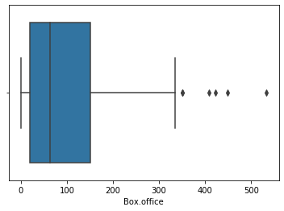

```python
sns.boxplot(filmy['Box.office'])
filmy.loc[filmy['Box.office']>340]
```

Część filmów jest już znajoma, m.in. z faktu bycia outlierami w zmiennej Glosy. Czyżby popularność ciągnęła ze sobą większy przychód? Jest to wniosek dość logiczny, jednak należy go poprzeć ewentualnym wykresem.

```
array([[1.        , 0.62756718],
       [0.62756718, 1.        ]])
```

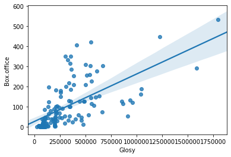

```python
sns.regplot(filmy['Glosy'], filmy['Box.office'])
np.corrcoef(filmy['Glosy'], filmy['Box.office'])
```

Rzeczywiście, korelacja jest spora. Idąc tym tokiem, najmniej kasowe filmy będą zapewne przypominać filmy najmniej popularne.

```python
filmy.sort_values('Box.office').head(5)
```

|  | Aktor | Rezyser | Tytul | Gatunek | Dlugosc | Ocena | Glosy | Box.office | Ocena_rezysera | Ocena_aktora | Oscary |
| --- | --- | --- | --- | --- | --- | --- | --- | --- | --- | --- | --- |
| 33 | Geoffrey Rush | Giuseppe Tornatore | La migliore offerta | Crime,Drama,Mystery | 131 | 7.8 | 77986 | 0.09 | 8.35 | 8.71 | 0 |
| 95 | Tom Hardy | Nicolas Winding Refn | Bronson | Action,Biography,Crime | 92 | 7.1 | 93972 | 0.10 | 7.86 | 8.80 | 0 |
| 103 | Charlotte Gainsbourg | Lars von Trier | Nymphomaniac: Vol. II | Drama | 123 | 6.7 | 65824 | 0.33 | 7.70 | 7.09 | 0 |
| 99 | Willem Dafoe | Lars von Trier | Antichrist | Drama,Horror | 108 | 6.6 | 94069 | 0.40 | 7.70 | 8.07 | 0 |
| 104 | Charlotte Gainsbourg | Lars von Trier | Nymphomaniac: Vol. I | Drama | 117 | 7.0 | 90556 | 0.79 | 7.70 | 7.09 | 0 |

Lars von Trier to dobrze nam już znany reżyser. Można zauważyć, że oprócz słabej popularności jego filmy cechują się też niskim box officem (mimo to, film zaliczany jest do 1000 najlepszych filmów na IMDB: stanowi słabszą część najlepszych filmów).

Czy reżyserzy też mają jakiś związek z box officem? Którzy z nich reżyserują najbardziej kasowe filmy?

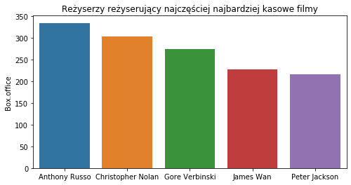

```python
zarobki_rezyserow = filmy['Box.office'].groupby(filmy['Rezyser']).mean().sort_values(ascending=False)
plt.figure(figsize=(8, 4))
sns.barplot(zarobki_rezyserow.head(5).index, zarobki_rezyserow.head(5))
plt.title("Reżyserzy reżyserujący najczęściej najbardziej kasowe filmy")
plt.xlabel("")
```

Wszyscy spośród podanych wyżej reżyserów stworzyli więcej niż jeden film w stawce, więc nie można tu mówić o kwestii wyreżyserowania wyłącznie jednego hitu. Czy tak samo jest jednak u aktorów?

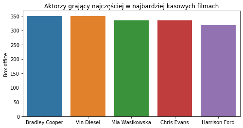

```python
zarobki_aktorow = filmy['Box.office'].groupby(filmy['Aktor']).mean().sort_values(ascending=False)
plt.figure(figsize=(8, 4))
sns.barplot(zarobki_aktorow.head(5).index, zarobki_aktorow.head(5))
plt.title("Aktorzy grający najczęściej w najbardziej kasowych filmach")
plt.xlabel("")
```

U aktorów sprawa wygląda trochę inaczej. Z tej stawki tylko Chris Evans gral w więcej niż jednym filmie (obie części Kapitana Ameryki: Civil War i Winter Soldier).

Ciekawie mogą też prezentować się wykresy pokazujące zależność między oceną aktora/reżysera a box officem.

```
array([[1.        , 0.25158399],
       [0.25158399, 1.        ]])
```

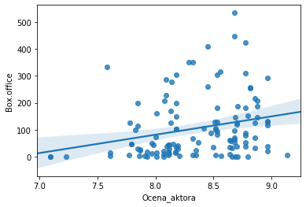

```python
sns.regplot(filmy['Ocena_aktora'], filmy['Box.office'])
np.corrcoef(filmy['Ocena_aktora'], filmy['Box.office'])
```

```
array([[1.        , 0.18495998],
       [0.18495998, 1.        ]])
```

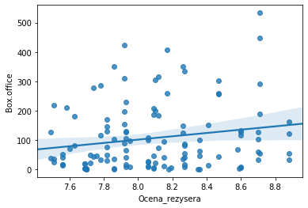

```python
sns.regplot(filmy['Ocena_rezysera'], filmy['Box.office'])
np.corrcoef(filmy['Ocena_rezysera'], filmy['Box.office'])
```

O ile w przypadku aktora widać, że filmy z dużym box officem mają częśto lepszych aktorów, w przypadku reżysera nie widać takiej zależności. Może będzie ją widać, jeśli zbadamy zmienną Dlugosc? Możliwe, że wkład czasowy przekłada się na sukces kasowy.

```
array([[1.       , 0.3449964],
       [0.3449964, 1.       ]])
```

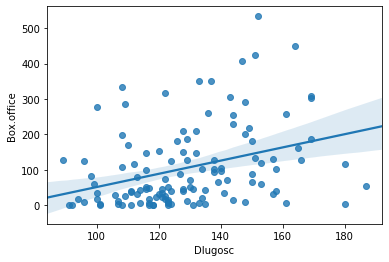

```python
sns.regplot(filmy['Dlugosc'], filmy['Box.office'])
np.corrcoef(filmy['Dlugosc'], filmy['Box.office'])
```

Korelacja nie jest zbyt mocna, chociaż najbardziej kasowe filmy są dość długie. Pozostaje kwestia gatunku filmu.

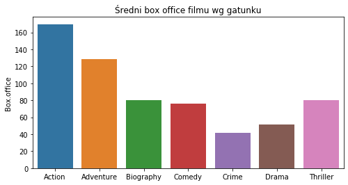

```python
plt.figure(figsize=(8, 4))
sns.barplot(filmy[['Box.office']].groupby(gatunek_filmu).mean().index,
        filmy['Box.office'].groupby(gatunek_filmu).mean())
plt.title("Średni box office filmu wg gatunku")
plt.xlabel("")
```

Na podstawie dotychczasowych wykresów na temat gatunku można wysnuć następujące wnioski:

- Action - średnie filmy słabszych reżyserów, ale z bardzo dobrą obsadą aktorską; popularne i kasowe; średniej długości
- Adventure - bardzo dobre filmy świetnych reżyserów, z dobrą obsadą aktorską; również popularne i kasowe; średniej długości
- Biography - bardzo dobre filmy słabszych reżyserów, ale z wyśmienitą obsadą aktorską; niezbyt popularne i średnio kasowe; długie
- Comedy - słabsze filmy słabszych reżyserów, z dobrą obsadą aktorską; mało popularne i średnio kasowe; krótkie
- Crime - średnie filmy średnich reżyserów, z dobrą obsadą aktorską; średnio popularne ale mało kasowe; dość długie
- Drama - bardzo dobre filmy dobrych reżyserów, ze słabszą obsadą aktorską; średnio popularne ale mało kasowe; przeciętnej długości
- Thriller - słabsze filmy dobrych reżyserów z dobrą obsadą aktorską; średnio popularne i średnio kasowe; dość krótkie

Na koniec podsumowanie: najbardziej kasowy film dla każdego z gatunków:

```python
ind = filmy.groupby(gatunek_filmu)['Box.office'].transform(max) == filmy['Box.office']
filmy[ind][['Gatunek','Tytul','Box.office']].sort_values('Gatunek')
```

|  | Gatunek | Tytul | Box.office |
| --- | --- | --- | --- |
| 18 | Action,Crime,Drama | The Dark Knight | 533.32 |
| 113 | Adventure,Family,Fantasy | Alice in Wonderland | 334.19 |
| 27 | Biography,Drama,History | Lincoln | 182.20 |
| 100 | Comedy | The Hangover | 277.31 |
| 59 | Crime,Drama,Thriller | The Departed | 132.37 |
| 46 | Drama,Western | Django Unchained | 162.80 |
| 91 | Mystery,Thriller | The Da Vinci Code | 217.54 |

## 2.8 Oscary

Liczba zdobytych przez film Oscarów jest ostatnią zmienną objaśniającą, która znajduje się w zbiorze danych. Jej rozkład jest następujący:

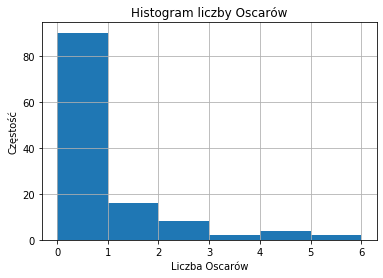

```python
filmy['Oscary'].hist(bins=6)
plt.title("Histogram liczby Oscarów")
plt.xlabel('Liczba Oscarów')
plt.ylabel('Częstość')
```

Co było oczywiste, przeważająca liczba filmów nie posiada żadnego Oscara. Najprawdopodbniej każda wartość poza 0 i 1 będzie traktowana jako outlier.

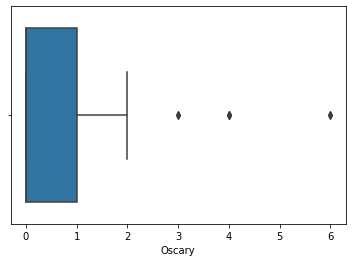

```python
sns.boxplot(filmy['Oscary'])
```

Jednak wartość "2" również zalicza się do normy. Dobrym rozwiązaniem może być zamienienie zmienne Oscary na zmienną kategoryczną. Nie ma dużej różnicy między dostaniem 3 albo 4 Oscarów, a liczba większej liczby Oscarów jest bardzo mała. Dlatego dalsza część analizy będzie przeprowadzana na zmienionej zmiennej, z poziomami 0, 1 i 2+. Odpowiednie przekształcenie zostanie dokonane poniżej.

```python
oscary = filmy['Oscary'].replace([3,4,5,6], 2)
```

Poniżej znajduje się krótkie podsumowanie zmiennych wg liczby Oscarów.

```
(6, 8.5)
```

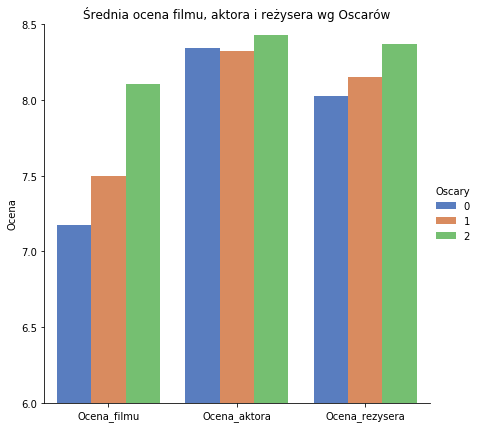

```python
dane = filmy[['Ocena', 'Ocena_aktora', 'Ocena_rezysera']].groupby(oscary).mean()
dane['Oscary'] = dane.index
dane = pd.melt(dane, id_vars='Oscary')
dane['variable'] = dane['variable'].replace({'Ocena': 'Ocena_filmu'})
dane = dane.rename({'variable':'Ocena'}, axis='columns')
plt.figure(figsize=(8, 4))
sns.catplot(x="Ocena", y="value", hue="Oscary", data=dane,
                height=6, kind="bar", palette="muted")
plt.title("Średnia ocena filmu, aktora i reżysera wg Oscarów")
plt.xlabel("")
plt.ylabel("Ocena")
plt.ylim(6, 8.5)
```

Wygląda na to, że obecność Oscara o czymś świadczy. Najbardziej odbija się to na ocenie filmu. W przypadku oceny aktora jest niewielki spadek z zera do jednego, jednak różnica jest mikroskopijna. A czy Oscar częściej trafia do filmów dłuższych?

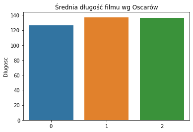

```python
sns.barplot(filmy['Dlugosc'].groupby(oscary).mean().index,
            filmy['Dlugosc'].groupby(oscary).mean())
plt.title("Średnia długość filmu wg Oscarów")
plt.xlabel("")
```

Filmy, które posiadają chociaż jednego Oscara, są średnio o 10 minut dłuższe od filmów bez zdobytej statuetki.

Ciekawym zagadnieniem jest też zbadanie zależności między gatunkami a Oscarami.

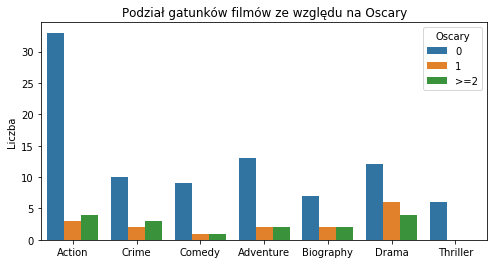

```python
filmy_gatunki['Oscary'] = oscary
plt.figure(figsize=(8, 4))
sns.countplot('Gatunek',hue='Oscary',data=filmy_gatunki)
plt.legend(['0','1','>=2'], title="Oscary", loc='upper right')
plt.title("Podział gatunków filmów ze względu na Oscary")
plt.xlabel("")
plt.ylabel("Liczba")
plt.show()
```

Zauważyć można, że Oscary szczególnie upodobały sobie dramaty. Z daleka omijają za to thrillery, a czasem zaglądną do komedii.

Na koniec wisienka na torcie, czyli sprawdzenie, który z Oscarowych filmów ma ocenę najniższą, a który najniższą.

```python
filmy[filmy['Oscary']>1][['Tytul','Ocena','Oscary']].sort_values('Ocena').head(1)
```

|  | Tytul | Ocena | Oscary |
| --- | --- | --- | --- |
| 113 | Alice in Wonderland | 6.5 | 2 |

```python
filmy[filmy['Oscary']>1][['Tytul','Ocena','Oscary']].sort_values('Ocena').tail(1)
```

|  | Tytul | Ocena | Oscary |
| --- | --- | --- | --- |
| 18 | The Dark Knight | 9.0 | 2 |

Tym samym film z Batmanem zakończył część dotyczącą eksploracyjnej analizy danych i inżynierii cech. Mamy już pewien pogląd na dane, a także parę pomysłów na dodatkowe zmienne bądź transformacje. Tematem kolejnego etapu będzie przekształcenie danych do odpowiedniej postaci.

# 3. Przygotowanie danych

Czas wykorzystać zdobytą wiedzę do przygotowania danych do trenowania modelu. Na tym etapie zbiór danych pozostaje wciąż niezmieniony od początku projektu. W trakcie eksploracyjnej analizy danych i inżynierii cech nie zostały wprowadzone żadne zmiany. Potoki (pipelines) pomogą mi zastosować wszystkie transformacje zmiennych, które zaproponowałem w poprzednim rozdziale i dodać zasugerowane przeze mnie zmienne.

Aby użyć potoków, załadowane zostaną najpierw odpowiednie biblioteki.

```python
from sklearn.base import BaseEstimator, TransformerMixin
from sklearn.compose import ColumnTransformer
from sklearn.pipeline import Pipeline
from sklearn.preprocessing import OneHotEncoder
from sklearn.pipeline import FeatureUnion
from sklearn.preprocessing import StandardScaler
```

Potoki pracują z klasami. Odpowiednie klasy wskazują, w jaki sposób dane powinny być przekształcane, a potoki stosują te przekształcenia. W niniejszym rozdziale wyróżnione zostaną cztery następujące części:

- Usunięcie obserwacji odstających
- Klasy
- Potoki
- Transformacja danych

## 3.1 Usunięcie obserwacji odstających

Pierwszym etapem przygotowania danych będzie usunięcie outlierów. Na podstawie tego, co zaprezentowano we wcześniejszym rozdziale, oraz wielu prób, poniższy kod dał najlepszy rezultat w postaci najniższego RMSE, jednocześnie usuwając jedynie parę obserwacji.

```python
#Ze wzgledu na ocene:
filmy = filmy.loc[filmy['Ocena']>=5.5]
#Ze wzgledu na ocene aktora:
filmy = filmy.loc[filmy['Aktor']!='Charlotte Gainsbourg']
#Ze wzgledu na Box.office (logarytm, bo ogon jest spory):
filmy = filmy.loc[np.log(filmy['Box.office'])>0.5]

filmy = filmy.reset_index(drop=True)
```

W ten sposób ze zbioru danych usunięto 10 filmów, co stanowi 8% zbioru danych.

## 3.2 Klasy

Czas na przedstawienie odpowiednich klas. Powielają one przekształcenia opisane w poprzednim rozdziale, więc w tej części nie będzie żadnej niespodzianki.

```python
class Duety_filmowe(BaseEstimator, TransformerMixin):
    def __init__(self, attribute_names):
        self._attribute_names = attribute_names
    def fit(self, X, y=None):
        return self
    def transform(self, X):
        duety = (X['Rezyser'] + ' + ' + X['Aktor']).value_counts()
        duety = duety.loc[duety>1]
        czy_duet = list()
        aktorzy = list(X[self._attribute_names])
        for i in range(0, len(aktorzy)):
            if ((X['Rezyser'][i] + ' + ' + aktorzy[i]) in duety.index):
                czy_duet.append(1)
            else:
                czy_duet.append(0)
        X.loc[:, 'Duet'] = czy_duet
        return X.values

class Liczebnosc_gatunkow(BaseEstimator, TransformerMixin):
    def __init__(self, attribute_names):
        self._attribute_names = attribute_names
    def fit(self, X, y=None):
        return self
    def transform(self, X):
        liczba_gatunkow = list()
        gatunki = list(X[self._attribute_names])
        for i in range(0, len(gatunki)):
            liczba_gatunkow.append(gatunki[i].count(",")+1)
        X.loc[:, 'Liczba_gatunkow'] = liczba_gatunkow
        return X.values

class Ustalenie_gatunku(BaseEstimator, TransformerMixin):
    def __init__(self, attribute_names):
        self._attribute_names = attribute_names
    def fit(self, X, y=None):
        return self
    def transform(self, X):
        gatunek_filmu = X[self._attribute_names].str.split(',', expand=True)[0]
        filmy_grozy_ind = gatunek_filmu[(gatunek_filmu=='Mystery') |
        (gatunek_filmu=='Horror') | (gatunek_filmu=='Thriller')].index
        animacja_ind = gatunek_filmu[gatunek_filmu=='Animation'].index
        gatunek_filmu.iloc[filmy_grozy_ind] = 'Thriller'
        gatunek_filmu.iloc[animacja_ind] = 'Comedy'
        X.loc[:,'Gatunek'] = gatunek_filmu
        return X.values

class Logarytm(BaseEstimator, TransformerMixin):
    def __init__(self, attribute_names):
        self._attribute_names = attribute_names
    def fit(self, X, y=None):
        return self
    def transform(self, X):
        X[self._attribute_names] = np.log(X[self._attribute_names])
        return X.values

class Oscary_kodowanie(BaseEstimator, TransformerMixin):
    def __init__(self, attribute_names):
        self._attribute_names = attribute_names
    def fit(self, X, y=None):
        return self
    def kodowanie(self, obj):
        if (obj == 0):
            Oscary_k = 'zero'
        elif (obj == 1):
            Oscary_k = 'jeden'
        else:
            Oscary_k = 'wiecej'
        return Oscary_k
    def transform(self, X):
        X.loc[:, 'Oscary_k'] = X[self._attribute_names].apply(self.kodowanie)
        return X.values
```

Tworzenie klas było dość miejscochłonne. Przy tworzeniu potoków jednak również należy zabezpieczyć nieco wolnego miejsca.

## 3.3 Potoki

Pora na przełożenie klas w praktykę.

```python
#Potoki tworzące/transformujące zmienne
aktor = 'Aktor'
aktor_pipeline = Pipeline(steps=[
    ('Duety_filmowe', Duety_filmowe(aktor))
])

gatunek = 'Gatunek'
gatunek_pipeline = Pipeline(steps=[
    ('Liczebnosc_gatunkow', Liczebnosc_gatunkow(gatunek))
])

gatunek_pipeline2 = Pipeline(steps=[
    ('Ustalenie_gatunku', Ustalenie_gatunku(gatunek))
])

box_office = 'Box.office'
box_office_pipeline = Pipeline(steps=[
    ('Logarytm', Logarytm(box_office))
])

glosy = 'Glosy'
glosy_pipeline = Pipeline(steps=[
    ('Logarytm', Logarytm(glosy))
])

oscary = 'Oscary'
oscary_pipeline = Pipeline(steps=[
    ('Oscary_kodowanie', Oscary_kodowanie(oscary))
])

#Kategoryczne zmienne - wymagają One Hot Encodingu. Wszystkie zmienne są normalizowane
atrybuty1 = ['Gatunek','Liczba_gatunkow']#, 'Oscary_k'
atrybuty1_pipeline = Pipeline(steps=[
    ('encoder', OneHotEncoder(sparse=False)),
    ('standarizer', StandardScaler())
])

#Numeryczne zmienne - w tym przypadku jedynie normalizacja
atrybuty2 = ['Duet','Dlugosc','Glosy','Box.office','Ocena_aktora','Ocena_rezysera', 'Oscary']
atrybuty2_pipeline = Pipeline(steps=[
    ('standarizer', StandardScaler())
])

#Polaczenie przeplywow dla zmiennych kategorycznych i numerycznych, a takze usuniecie niepotrzebnych kolumn
preprocessor = ColumnTransformer(
    remainder = 'drop',
    transformers=[
        ('first', atrybuty1_pipeline, atrybuty1),
        ('second', atrybuty2_pipeline, atrybuty2)
])

#Laczenie wszystkich przeplywow
full_pipeline = FeatureUnion([
    ('aktor_pipeline', aktor_pipeline),
    ('gatunek_pipeline', gatunek_pipeline),
    ('gatunek_pipeline2', gatunek_pipeline2),
    ('box_office_pipeline', box_office_pipeline),
    ('glosy_pipeline', glosy_pipeline),
    #('oscary_pipeline', oscary_pipeline),
    ('preprocessor', preprocessor)
])

#Przeplyw usuwajacy niepotrzebne kolumny (jedno uzycie jest niewystarczajace). Zmienne nie sa ponownie skalowane,
#sam to sprawdzalem
full_pipeline2 = FeatureUnion([
    ('preprocessor', preprocessor)
])
```

Na pewno dało się zauważyć, że niektóre z atrybutów i potoków w full_pipeline są wsadzone jako komentarz. Nie oznacza to, że te linie nie zostały wcale użyte w kodzie. W niniejszym projekcie przedstawione jest rozwiązanie, które dało najlepszy rezultat. Metodą prób i błędów doszedłem do rozwiązania przedstawionego powyżej. Najlepszy wynik uzyskano bez zamieniania zmiennej Oscary na zmienną kategoryczną. W ten sposób w końcowym modelu zostały użyte następujące zmienne:

- Gatunek - główny gatunek filmu
- Dlugosc - podany w minutach czas trwania filmu
- Glosy - logarytm liczby głosów oddanych na daną produkcję
- Box.office - logarytm przychodu ze sprzedaży filmu, liczony w milionach dolarów
- Ocena_rezysera - ocena reżysera filmu w skali 1-10
- Ocena_aktora - ocena głównego aktora/aktorki filmu w skali 1-10
- Oscary - liczba zdobytych przez film Oscarów
- Liczba_gatunkow - liczba gatunków przyporządkowanych do filmu
- Duet - czy reżyser i aktor spotkali się już kiedyś na planie filmu

## 3.3 Transformacja danych

Pożądany zbiór danych zostanie uzyskany przy użyciu dwóch potoków, jednego po drugim: najpierw full_pipeline do tworzenia i przekształcania odpowiednich zmiennych, a następnie full_pipeline2 do usuwania niepotrzebnych zmiennych.

```python
filmy_przygotowane = full_pipeline.fit_transform(filmy)
filmy_przygotowane = full_pipeline2.fit_transform(filmy)
X_filmy_przygotowane = filmy_przygotowane
y_filmy_przygotowane = filmy['Ocena']

X_filmy_przygotowane.shape
```

```
(112, 17)
```

Gotowe! Cały wysiłek związany z dotychczasową analizą danych zawarty jest w powyższym małym fragmencie kodu. Nadał on danym pożądany kształt, który będzie odpowiedni dla tworzonych modeli. Wyodrębniono dwa zestawy danych. Pierwszy z nich, oznaczony znakiem X, jest zestawem zmiennych objaśniających. Będzie on używany do modelowania. Drugi, oznaczony literą y, będzie pomocny w ocenie modeli.

Po przygotowaniu danych nie pozostaje nic innego, jak przejść do ich modelowania.

# 4. Trenowanie, ewaluacja i dostrajanie modelu

W rzeczywistości część oceny modelu jest już wykonana. W poprzednim rozdziale wskazane zostały zmienne, które pozwoliły uzyskać najlepszy wynik. To była oczywiście część ewaluacji modelu. Ale w tym rozdziale w centrum zainteresowania będą same modele. Zwykły model liniowy, Elastic Net, regresja Random Forest oraz SVR - wypróbowałem wszystkie te dość podstawowe algorytmy. W niniejszym projekcie zaprezentuję każdy z nich, skupiając się jednak na kombinacji, która dała mi pożądany rezultat. Udało mi się to osiągnąć przy pomocy regresji Random Forest, która od samego początku wyprzedzała inne testowane przeze mnie metody.

## 4.1 Wybór cech

```python
from sklearn.linear_model import LinearRegression
from sklearn.model_selection import GridSearchCV
from sklearn.model_selection import cross_val_score
from sklearn.metrics import mean_squared_error
from sklearn.ensemble import RandomForestRegressor
from sklearn.svm import SVR
from sklearn.linear_model import ElasticNet
from sklearn.neighbors  import KNeighborsRegressor

##############
#Random Forest
##############
rf_model = RandomForestRegressor(random_state=42)

params_grid = [
        {'n_estimators': [100, 200, 300, 400, 500],
         'criterion': ['mse', 'mae'],
         'min_samples_split': [2, 3, 4, 5],
         'max_features': ['auto', 'log2', 'sqrt'],
         'bootstrap': ['True', 'False']}
]

grid_search = GridSearchCV(rf_model, params_grid, cv=5, scoring="neg_mean_squared_error", n_jobs=1)
grid_search.fit(X_filmy_przygotowane, y_filmy_przygotowane)
grid_search.best_params_
```

```
{'bootstrap': 'True',
 'criterion': 'mse',
 'max_features': 'auto',
 'min_samples_split': 3,
 'n_estimators': 200}
```

Blok poniżej będzie zawierać właściwy kod. Ten powyżej miał jedynie służyć ustaleniu wstępnych parametrów.

```python
params_grid2 = [
        {'n_estimators': [120, 140, 160, 180, 200, 220, 240, 260, 280],
         'criterion': ['mse', 'mae'],
         'min_samples_split': [2, 3],
         'max_features': ['auto'],
         'bootstrap': ['True']}
]

grid_search2 = GridSearchCV(rf_model, params_grid2, cv=5, scoring="neg_mean_squared_error", n_jobs=1)
grid_search2.fit(X_filmy_przygotowane, y_filmy_przygotowane)

def indices_of_top_k(arr, k):
    return np.sort(np.argpartition(np.array(arr), -k)[-k:])

def fs_calculate_results():
    cv_mean = list()
    cv_std = list()
    rf_model = RandomForestRegressor()
    feature_importances = grid_search2.best_estimator_.feature_importances_
    for i in range(1,18):
       indices_of_top = indices_of_top_k(feature_importances, i)
       X_filmy_restricted = X_filmy_przygotowane[:, indices_of_top]
       params_grid_fs = [
        {'n_estimators': [120, 140, 160],
         'criterion': ['mse', 'mae'],
         'min_samples_split': [2, 3],
         'max_features': ['auto'],
         'bootstrap': ['True']}
        ]
       #print(i)
       grid_search_fs = GridSearchCV(rf_model, params_grid_fs, cv=5, scoring="neg_mean_squared_error", n_jobs=1)
       grid_search_fs.fit(X_filmy_restricted, y_filmy_przygotowane)
       rf_best_model = grid_search_fs.best_estimator_
       rf_cv = cross_val_score(rf_best_model, X_filmy_restricted, y_filmy_przygotowane,
                             scoring="neg_mean_squared_error", cv=10)
       rf_cv = np.sqrt(-rf_cv)
       cv_mean.append(rf_cv.mean())
       cv_std.append(rf_cv.std())
    return cv_mean, cv_std

cv_mean, cv_std = fs_calculate_results()
fs_results = pd.DataFrame({'cv_mean': cv_mean, 'cv_std': cv_std})
fs_results.index += 1
fs_results = fs_results.sort_values('cv_mean')
fs_results
```

|  | cv_mean | cv_std |
| --- | --- | --- |
| 10 | 0.426561 | 0.098744 |
| 8 | 0.428468 | 0.107009 |
| 13 | 0.428757 | 0.105711 |
| 11 | 0.430007 | 0.098810 |
| 7 | 0.430639 | 0.094992 |
| 12 | 0.430889 | 0.106047 |
| 15 | 0.431080 | 0.112748 |
| 9 | 0.433134 | 0.107189 |
| 16 | 0.433947 | 0.108798 |
| 5 | 0.434242 | 0.110804 |
| 3 | 0.434862 | 0.099750 |
| 17 | 0.435126 | 0.101762 |
| 14 | 0.437879 | 0.092060 |
| 6 | 0.440768 | 0.083450 |
| 4 | 0.446491 | 0.108599 |
| 2 | 0.468371 | 0.084410 |
| 1 | 0.519164 | 0.102974 |

W wygenerowanej powyżej tabeli numer indeksu jest liczbą branych pod uwagę zmiennych (od 1 do 17). Druga kolumna pokazuje średni wynik 10-krotnej walidacji krzyżowej, natomiast kolumna trzecia pokazuje odchylenie standardowe dla wyniku z kolumny numer 2. Wiersze w ramce danych zostały posortowane według drugiej kolumny. Najlepsze są najmniejsze średnie wartości, jednak posiadające jednocześnie małe odchylenie standardowe.

## 4.2 Model Random Forest

```python
#Ograniczenie zbioru danych
feature_importances = grid_search2.best_estimator_.feature_importances_
indices_of_top = indices_of_top_k(feature_importances, 11)
X_filmy_przygotowane_RF = X_filmy_przygotowane[:, indices_of_top]

rf_model = RandomForestRegressor(random_state=42)
params_grid = [
        {'n_estimators': [400, 420, 440],
         'criterion': ['mse', 'mae'],
         'min_samples_split': [2, 3],
         'max_features': ['auto'],
         'bootstrap': ['True']}
]

grid_search = GridSearchCV(rf_model, params_grid, cv=5, scoring="neg_mean_squared_error", n_jobs=1)
grid_search.fit(X_filmy_przygotowane_RF, y_filmy_przygotowane)
rf_model = grid_search.best_estimator_

#Funkcja wypisujaca wynik
def wyniki_sprawdzianu_krzyzowego(wyniki):
    print("Wyniki:", wyniki)
    print("Średnia:", wyniki.mean())
    print("Odchylenie standardowe:", wyniki.std())

rf_cv = cross_val_score(rf_model, X_filmy_przygotowane, y_filmy_przygotowane,
                             scoring="neg_mean_squared_error", cv=10)
rf_cv = np.sqrt(-rf_cv)

rf_wyniki = wyniki_sprawdzianu_krzyzowego(rf_cv)
rf_wyniki
```

```
Wyniki: [0.38968011 0.32741278 0.44171017 0.26473669 0.49633642 0.31860638
 0.57840634 0.45488367 0.44578301 0.59457477]
Średnia: 0.43121303242677184
Odchylenie standardowe: 0.10313625225402889
```

## 4.3 Regresja liniowa

Nie można obyć się bez podstawowego modelu. W przypadku modeli innych niż Random Forest również stosowano ograniczanie liczby ważnych parametrów, jednak wynik uzyskany przez Random Forest nie został pobity, dlatego dla uproszczenia przedstawiona zostanie prostsza wersja.

```python
lin_reg = LinearRegression()
params_grid = [
        {'fit_intercept': [True, False]}
]
grid_search = GridSearchCV(lin_reg, params_grid, cv=5, scoring="neg_mean_squared_error", n_jobs=1)
grid_search.fit(X_filmy_przygotowane, y_filmy_przygotowane)

lin_reg_model = grid_search.best_estimator_
lin_reg_cv = cross_val_score(lin_reg_model, X_filmy_przygotowane, y_filmy_przygotowane,
                             scoring="neg_mean_squared_error", cv=10)
lin_reg_cv = np.sqrt(-lin_reg_cv)

lin_reg_wyniki = wyniki_sprawdzianu_krzyzowego(lin_reg_cv)
lin_reg_wyniki
```

```
Wyniki: [0.55705999 0.51101624 0.37784376 0.31539889 0.54478129 0.31945631
 0.45253377 0.4814263  0.36792644 0.70582964]
Średnia: 0.46332726452912903
Odchylenie standardowe: 0.11659189439678973
```

## 4.4 Regresja Elastic Net

Elastic Net to metoda, która pozwala na kontrolowanie modelu w celu uniknięcia jego przeuczenia, dzięki zastosowaniu regularyzacji. Model poddany regularyzacji jest modelem, którego funkcja straty zawiera dodatkowy element, który również będzie zminimalizowany. Wynikiem tego jest „karanie” funkcji straty dla wysokich wartości współczynników β. Regresja Elastic Net jest kompromisem między Lasso Regression i Ridge Regression. Człon regularyzacyjny tworzy tu kombinacja członów obydwu wspomnianych technik, a kierować nim można za pomocą współczynnika proporcji.

```python
en_model = ElasticNet(random_state=42)

params_grid = [
        {'alpha': [0.1, 0.2, 0.3, 0.4, 0.5, 0.6, 0.7, 0.8, 0.9, 1],
         'l1_ratio': [0, 0.1, 0.2, 0.3, 0.4, 0.5, 0.6, 0.7, 0.8, 0.9, 1],
         'fit_intercept': [True, False],
         'tol':[1],
         'max_iter': [500, 1000, 5000, 10000]}
]

grid_search = GridSearchCV(en_model, params_grid, cv=5, scoring="neg_mean_squared_error", n_jobs=1)
grid_search.fit(X_filmy_przygotowane, y_filmy_przygotowane)
en_model = grid_search.best_estimator_

en_cv = cross_val_score(en_model, X_filmy_przygotowane, y_filmy_przygotowane,
                             scoring="neg_mean_squared_error", cv=10)
en_cv = np.sqrt(-en_cv)

en_wyniki = wyniki_sprawdzianu_krzyzowego(en_cv)
en_wyniki
```

```
Wyniki: [0.46995576 0.52103212 0.47316052 0.25695093 0.52923729 0.35906179
 0.5289861  0.49501623 0.33268279 0.59518966]
Średnia: 0.4561273193825436
Odchylenie standardowe: 0.1002644728607204
```

## 4.5 Support Vector Regression

SVR to regresyjna wersja algorytmu Support Vector Machine (SVM), w którym punkty danych są reprezentowane jako punkty w przestrzeni w taki sposób, że punkty z różnych kategorii są oddzielone płaszczyzną. Można o tym myśleć jak o linii przechodzącej przez punkty danych, które oddzielają dane różnych klas. Nowe dane są mapowane w tej samej przestrzeni, a ich położenie względem płaszczyzny służy do przewidywania, do których kategorii należy każdy punkt, przy czym płaszczyzna jest określana jako granica decyzji (tj. określanie, do której klasy należą dane). W przypadku, gdy granica decyzji musi być nieliniowa (tzn. klasy nie mogą być oddzielone linią prostą), maszyny SVM mają również możliwość rzutowania przestrzeni przez funkcję nieliniową, podnosząc dane do przestrzeni o wyższym wymiarze, gdzie liniowa granica decyzji oddziela klasy.

```python
svr_model = SVR()

params_grid = [
        {'kernel': ['linear', 'poly', 'rbf', 'sigmoid'],
         'gamma': ['scale', 'auto'],
         'shrinking': [True, False],
         'C': [0.1, 0.2, 0.3, 0.4, 0.5, 0.6, 0.7, 0.8, 0.9, 1]}
]

grid_search = GridSearchCV(svr_model, params_grid, cv=5, scoring="neg_mean_squared_error", n_jobs=1)
grid_search.fit(X_filmy_przygotowane, y_filmy_przygotowane)
grid_search.best_params_
#{'C': 0.3, 'gamma': 'scale', 'kernel': 'linear', 'shrinking': False}
svr_model = grid_search.best_estimator_

svr_cv = cross_val_score(svr_model, X_filmy_przygotowane, y_filmy_przygotowane,
                             scoring="neg_mean_squared_error", cv=10)
svr_cv = np.sqrt(-svr_cv)

svr_wyniki = wyniki_sprawdzianu_krzyzowego(svr_cv)
svr_wyniki
```

```
Wyniki: [0.5195097  0.4624608  0.45376466 0.27573897 0.50031396 0.36842177
 0.47378028 0.43214937 0.31014981 0.68866158]
Średnia: 0.44849509008179644
Odchylenie standardowe: 0.11042344738655939
```

# Zakończenie

W niniejszym projekcie przedstawiono budowę modeli dla przeanalizowanego wcześniej zbioru danych. Użycie web scrappingu w połączeniu z gotową bazą najlepszych filmów IMDB pozwoliło na urozmaicenie zbioru danych, a także na jego przemieszanie. Dzięki temu możliwe było przedstawienie unikatowego projektu, który zaprezentował możliwości Machine Learningu, zachowując kolejność właściwą dla każdego projektu uczenia maszynowego. W tym przypadku jednak postanowiono ograniczyć się do jednego zbioru danych, nie eksperymentując z podziałem na zbiór treningowy i testowy. Wykonano jedna sprawdzianu krzyżowey, który ocenił jakość tworzonych modeli.

Wykazano, że w niniejszym przypadku najlepiej sprawdziła się regresja Random Forest. Niewykluczone, że istnieją modele jeszcze lepsze, a dostrajanie można było przeprowadzić jeszcze dokładniej. Zadania te leżą już jednak poza dziedziną projektu, który na chwilę obecną jest jedynie projektem na zaliczenie przedmiotu, z planami na dalszy jego rozwój.